# ML_project_1

## PROJECT 1: Climate Weather Surface of Brazil - Hourly

## By: Lade Sule, DSC 3344

```python
import pandas as pd
import numpy as np
%matplotlib inline
import matplotlib.pyplot as plt
plt.style.use("seaborn-v0_8-whitegrid")
from sklearn.linear_model import LinearRegression
from sklearn.linear_model import LogisticRegression
from sklearn.model_selection import train_test_split
import seaborn as sn
from mlxtend.feature_selection import SequentialFeatureSelector as SFS
from sklearn.ensemble import RandomForestClassifier
from sklearn.metrics import r2_score
import statsmodels.api as sm
from statsmodels.formula.api import ols
```

[figure not shown]

```python
import urllib.request
from IPython.display import Image
from IPython.display import display

url = 'https://media-cldnry.s-nbcnews.com/image/upload/t_fit-1500w,f_auto,q_auto:best/rockcms/2022-10/221031-brazil-luiz-inancio-da-silva-ac-604p-0f0864.jpg'
filename = "google_wacodrought.png"
urllib.request.urlretrieve(url, filename)

display(Image(filename))
```

### The typical climate and weather during the off-season and on-season times in Brazil can vary significantly depending on the region and the specific destination. In many tourist destinations, the on-season typically corresponds to the peak travel months when weather conditions are most favorable. During the on-season, you can expect milder temperatures, fewer rainfall events, and generally pleasant conditions, making it ideal for outdoor activities and sightseeing. Conversely, the off-season often sees less tourist traffic due to less desirable weather conditions. It might include periods of colder temperatures, increased rainfall, or extreme heat, depending on the location. Traveling during the off-season can offer cost savings and a more serene atmosphere but may require careful planning to navigate the weather-related challenges. When planning a trip or a visit to Brazil, it's essential to consider the specific destination's climate patterns to choose the season that aligns with your preferences and interests.

```python
from google.colab import drive
drive.mount('/content/drive')
```

### To improve runtime efficiency, 100,000 rows were read in from each of the data subsets. Originally, there would be total of over 6 million data points for this project. Despite employing data chunking and lazy evaluation methods, the runtime remained slow and also had a slow execution.

```python
import dask.dataframe as ddf
import pandas as pd
import psutil
north = pd.read_csv('/content/drive/My Drive/Colab Notebooks/north.csv',nrows=100000)
south = pd.read_csv('/content/drive/My Drive/Colab Notebooks/south.csv',nrows=100000)
northeast = pd.read_csv('/content/drive/My Drive/Colab Notebooks/northeast.csv',nrows=100000)
central_west = pd.read_csv('/content/drive/My Drive/Colab Notebooks/central_west.csv',nrows=100000)
southeast = pd.read_csv('/content/drive/My Drive/Colab Notebooks/southeast.csv',nrows=100000)
```

### After importing all the subsets, I merged them into a single dataset to facilitate side-by-side region comparisons and in-depth analysis. 5 brazilian regions were analyzed in this project. The North region, South region, Northeast region, Central west region, and the Southeast region. The goal is to look at major differences (if any) in any of these regions and perform an analysis on which region may be the most suitable based on preferences.

```python
north['region'] = 'north'
south['region'] = 'south'
northeast['region'] = 'northeast'
central_west['region'] = 'central_west'
southeast['region'] = 'southeast'
### merge into one dataframe
data = pd.concat([north, south, northeast,central_west,southeast])
```

```python
data.columns
```

```
Index(['index', 'Data', 'Hora', 'PRECIPITAÇÃO TOTAL, HORÁRIO (mm)',
       'PRESSAO ATMOSFERICA AO NIVEL DA ESTACAO, HORARIA (mB)',
       'PRESSÃO ATMOSFERICA MAX.NA HORA ANT. (AUT) (mB)',
       'PRESSÃO ATMOSFERICA MIN. NA HORA ANT. (AUT) (mB)',
       'RADIACAO GLOBAL (Kj/m²)',
       'TEMPERATURA DO AR - BULBO SECO, HORARIA (°C)',
       'TEMPERATURA DO PONTO DE ORVALHO (°C)',
       'TEMPERATURA MÁXIMA NA HORA ANT. (AUT) (°C)',
       'TEMPERATURA MÍNIMA NA HORA ANT. (AUT) (°C)',
       'TEMPERATURA ORVALHO MAX. NA HORA ANT. (AUT) (°C)',
       'TEMPERATURA ORVALHO MIN. NA HORA ANT. (AUT) (°C)',
       'UMIDADE REL. MAX. NA HORA ANT. (AUT) (%)',
       'UMIDADE REL. MIN. NA HORA ANT. (AUT) (%)',
       'UMIDADE RELATIVA DO AR, HORARIA (%)',
       'VENTO, DIREÇÃO HORARIA (gr) (° (gr))', 'VENTO, RAJADA MAXIMA (m/s)',
       'VENTO, VELOCIDADE HORARIA (m/s)', 'region', 'state', 'station',
       'station_code', 'latitude', 'longitude', 'height'],
      dtype='object')
```

### I conducted a check for NA (missing) values to identify data points with missing information. It is crucial to remove these NA values because they can adversely affect the quality and reliability of data analysis and modeling. Missing data can lead to biased results and inaccurate conclusions, so their removal or proper handling is essential to ensure the integrity of the analysis and the reliability of any models built using the dataset. Luckily, there were no missing values in this dataset.

```python
data.isna().sum()
```

```
index                                                    0
Data                                                     0
Hora                                                     0
PRECIPITAÇÃO TOTAL, HORÁRIO (mm)                         0
PRESSAO ATMOSFERICA AO NIVEL DA ESTACAO, HORARIA (mB)    0
PRESSÃO ATMOSFERICA MAX.NA HORA ANT. (AUT) (mB)          0
PRESSÃO ATMOSFERICA MIN. NA HORA ANT. (AUT) (mB)         0
RADIACAO GLOBAL (Kj/m²)                                  0
TEMPERATURA DO AR - BULBO SECO, HORARIA (°C)             0
TEMPERATURA DO PONTO DE ORVALHO (°C)                     0
TEMPERATURA MÁXIMA NA HORA ANT. (AUT) (°C)               0
TEMPERATURA MÍNIMA NA HORA ANT. (AUT) (°C)               0
TEMPERATURA ORVALHO MAX. NA HORA ANT. (AUT) (°C)         0
TEMPERATURA ORVALHO MIN. NA HORA ANT. (AUT) (°C)         0
UMIDADE REL. MAX. NA HORA ANT. (AUT) (%)                 0
UMIDADE REL. MIN. NA HORA ANT. (AUT) (%)                 0
UMIDADE RELATIVA DO AR, HORARIA (%)                      0
VENTO, DIREÇÃO HORARIA (gr) (° (gr))                     0
VENTO, RAJADA MAXIMA (m/s)                               0
VENTO, VELOCIDADE HORARIA (m/s)                          0
region                                                   0
state                                                    0
station                                                  0
station_code                                             0
latitude                                                 0
longitude                                                0
height                                                   0
dtype: int64
```

### After checking for N/A values, I generated a correlation matrix to examine the relationships between features and identify high dependencies. This analysis revealed that many features were likely to be irrelevant for the study. Looking at the matrix, it seemed it would be beneficial to keep the Latitude, Longitute, Radiaco Global (Sunlight), and a couple temperature features. The features stated also do not have a high dependency of one another. Going forward in this project, I will only be focused on a few features.

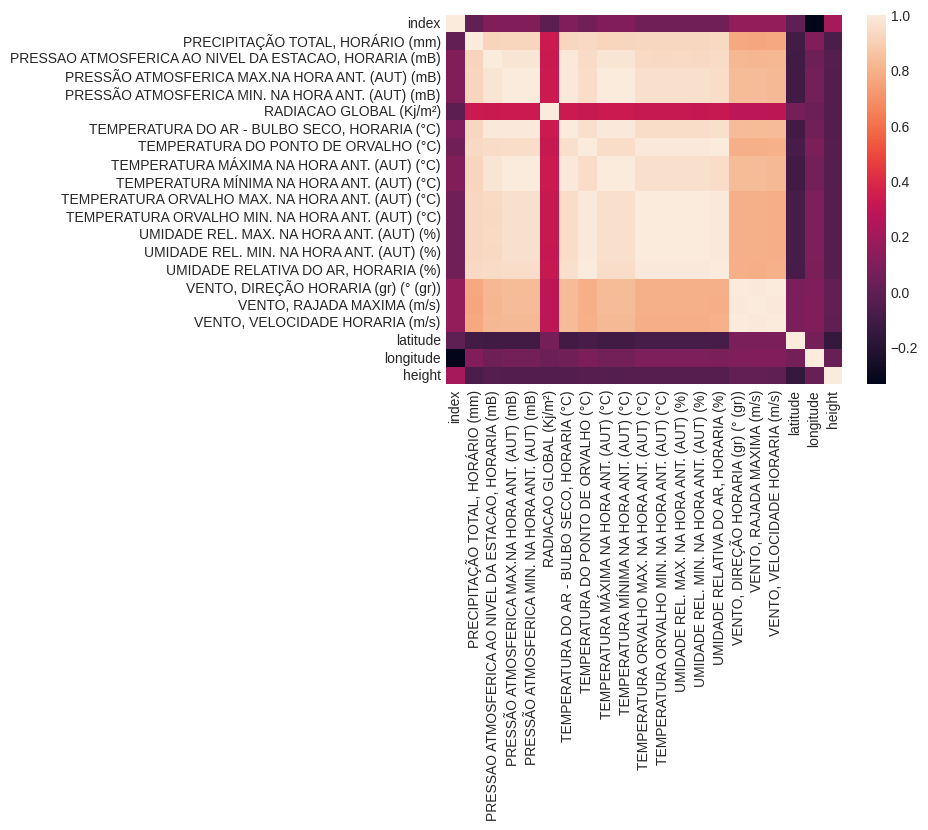

```python
correlation_matrix = data.corr()
correlation_matrix
sn.heatmap(correlation_matrix, annot = False)
```

### When doing some research, I found that precipitation, sunlight, humidity, and temperature are among the most critical factors people consider when selecting a region or area to live in or visit. Precipitation levels help individuals gauge the availability of water resources and the likelihood of floods or droughts, influencing agricultural practices and water management. Sunlight is a vital determinant of climate and daily life, affecting mood, outdoor activities, and even energy consumption. Humidity and temperature play a pivotal role in comfort and well-being, impacting health, clothing choices, and energy requirements for heating or cooling. Together, these weather-related features not only shape the physical environment but also have a profound influence on the lifestyle, economic activities, and overall desirability of a region, making them crucial considerations for anyone seeking to make a location-based decision.

### In the next steps of this analysis, I will be analyzing the temperatures/humidity, solar radiation, and precipitation from the dataset. Here, I filtered the temperature column to exclude values below -273 degrees because some data points fell below this threshold. Since temperatures cannot realistically reach such low levels, these data points were considered insufficient and were removed. Air temperatures are an important feature especially when discussing geographical regions.

```python
data['TEMPERATURA MÁXIMA NA HORA ANT. (AUT) (°C)'].describe()
data = data[data['TEMPERATURA MÁXIMA NA HORA ANT. (AUT) (°C)'] >= -273.15]
np.shape(data)
print(f"the minimum temperature of this feature is {data['TEMPERATURA MÁXIMA NA HORA ANT. (AUT) (°C)'].min()}")
```

```
the minimum temperature of this feature is -1.6
```

```python
data['UMIDADE RELATIVA DO AR, HORARIA (%)'].describe()
column_name = 'UMIDADE RELATIVA DO AR, HORARIA (%)'
data[column_name] = data.apply(lambda x: max(x[column_name], 0), axis=1)
```